# Midterm #2 Question 2 makeup

Luke Letizia

May 3, 2018

## Question 2

### Introduction

The car insurance company has already implemented a poisson regression model to describe the claim counts distribution. I have been hired to test whether the poisson model should be replaced by a homogeneous negative binomial model. I have concluded that a Negative Binomial model better fits the data and should be used to describe the claim counts distribution.

### Results

By comparing the poisson regression and the negative binomial, I have concluded that the negative binomial is favored over the poisson because the predicted values are much closer and more honed in to the actual data set than the poisson model is. The chi-square statistic for the negative binomial is also much closer to 0 which proves it is superior.

### Conclusion

Through the methods used and based on the statistical proof from the dataset provided, I conlcude that the homogeneous negative should replace the poisson regression model. By using the negative binomial, future premiums should thus decrease becuase it increases the predicted number that are accident free and decreases the number that have one or more accidents.

### Implementations

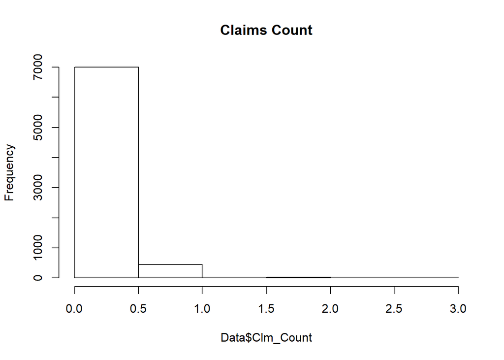

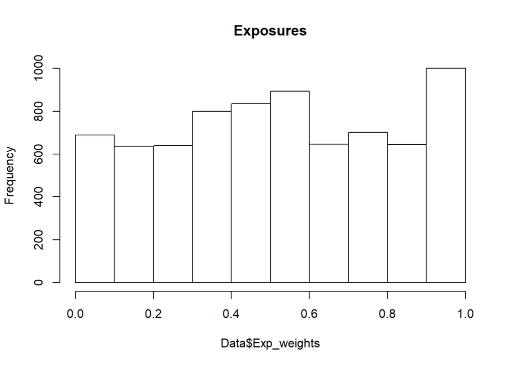

```
##  #Claims Observed
##        0     6996
##        1      455
##        2       28
##        3        4
```

### Implementing a Homogeneous Poisson Model

```
##  #Claims    Data Model without Exposure Model With Exposure
##     0.00 6996.00                6977.86             6983.05
##     1.00  455.00                 487.69              477.67
##     2.00   28.00                  17.04               21.52
##     3.00    4.00                   0.40                0.73
```

We can see that the model without exposure differs from the actual data observed. We can see that including exposures is necesarry for the model because it hones the values for each claim count closer to the observed values, but it is still not an adeqaute fit.

##### Chi Square Statistic without exposures:

```
## [1] 42
```

##### Chi Square Statistic with exposures:

```
## [1] 18
```

Because the Chi-Square Satistic is much lower with exposures, we can see that Exposures are an important factor to include when modeling the data.

### Generalized Linear Poisson Model

We now investigate modeling different risk parameters for different drivers based on factors involved.

#### Comparing the Homogeneous Poisson and Poisson Regression

```
##  #Claims    Data Model without Exposure Model With Exposure
##     0.00 6996.00                6977.86             6983.05
##     1.00  455.00                 487.69              477.67
##     2.00   28.00                  17.04               21.52
##     3.00    4.00                   0.40                0.73
##  Poisson Regression
##             6986.94
##              470.30
##               24.63
##                1.09
```

### Fit Negative Binomial

Max $\lambda$ = 0.13 Max $\gamma$ = 1.42

#### Plotted Log Likelihood Function for different values of $\lambda$ and $\gamma$

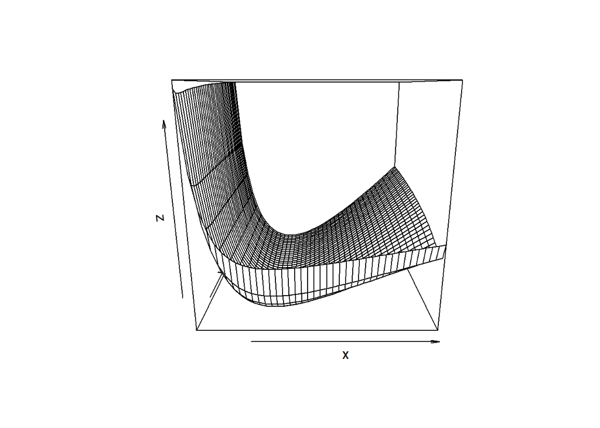

#### Comparing the Negative Binomial and the Poisson Regression

```
##  #Claims   Data Negative Binomial
##      0.0 6996.0            6997.3
##      1.0  455.0             451.0
##      2.0   28.0              32.1
##      3.0    4.0               2.4
```

```
##  #Claims   Data Poisson Regression Negative Binomial
##      0.0 6996.0             6986.9            6997.3
##      1.0  455.0              470.3             451.0
##      2.0   28.0               24.6              32.1
##      3.0    4.0                1.1               2.4
```

#### Negative Binomial Chi-Square Statistic

```
## [1] 1.6
```

#### Poisson Regression Chi-Square Statistic

```
## [1] 8.7
```

### Proofs

$E[N] = E[E[N|\theta]] = E[\theta\lambda] = \lambda E[\theta] = \lambda*1 = \lambda$

$Var[N] = E[Var[N|\theta]] + Var[E[N|\theta]] = E[Var[\theta\lambda]] + Var[E[[\theta\lambda]] = \lambda^21/\gamma + Var[\lambda] = \lambda^2 1/\gamma + \lambda = \lambda +(1 + \lambda/\gamma)$